# First Look

2022-05-16

## Motivating Example

- Kick things off by looking at a real data set in R
- Goal: get the flavor of using R for data management and exploration
- Don’t worry about understanding all the coding right away
- We will come back to see how everything works in detail

## Palmer Penguins

- Allison Horst: data on 344 penguins from three different species and three islands over three years
- https://allisonhorst.github.io/palmerpenguins/
- data consists of observations on nesting penguins
- several variables recorded:
  - body measures of penguins: bill length, bill depth, flipper length, and body mass
  - year
  - species
  - location
  - penguin’s sex (determined by blood test)
- **Primary Question**: Can sex be determined without blood test?

## Follow along

Copy & paste the code into the console:

```r
curl::curl_download(
  "https://raw.githubusercontent.com/heike/summerschool-2022/master/01-Introduction-to-R/code/1-example.R",
  "1-example.R"
)
file.edit("1-example.R")
```

## First look at data in R

Lets use R to look at the top few rows of the data set. First, we load the penguins data `read.csv`:

```r
penguins <- read.csv("https://raw.githubusercontent.com/heike/summerschool-2022/main/01-Introduction-to-R/data/penguins.csv", stringsAsFactors = TRUE)
```

Now, we use the `head` function to look at the first 6 rows of the data:

```r
head(penguins)
```

```
##   species    island bill_length_mm bill_depth_mm flipper_length_mm body_mass_g
## 1  Adelie Torgersen           39.1          18.7               181        3750
## 2  Adelie Torgersen           39.5          17.4               186        3800
## 3  Adelie Torgersen           40.3          18.0               195        3250
## 4  Adelie Torgersen             NA            NA                NA          NA
## 5  Adelie Torgersen           36.7          19.3               193        3450
## 6  Adelie Torgersen           39.3          20.6               190        3650
##      sex year
## 1   male 2007
## 2 female 2007
## 3 female 2007
## 4   <NA> 2007
## 5 female 2007
## 6   male 2007
```

## Penguins Data Attributes

How big is this data set and what types of variables are in each column?

```r
str(penguins)
```

```
## 'data.frame':    344 obs. of  8 variables:
##  $ species          : Factor w/ 3 levels "Adelie","Chinstrap",..: 1 1 1 1 1 1 1 1 1 1 ...
##  $ island           : Factor w/ 3 levels "Biscoe","Dream",..: 3 3 3 3 3 3 3 3 3 3 ...
##  $ bill_length_mm   : num  39.1 39.5 40.3 NA 36.7 39.3 38.9 39.2 34.1 42 ...
##  $ bill_depth_mm    : num  18.7 17.4 18 NA 19.3 20.6 17.8 19.6 18.1 20.2 ...
##  $ flipper_length_mm: int  181 186 195 NA 193 190 181 195 193 190 ...
##  $ body_mass_g      : int  3750 3800 3250 NA 3450 3650 3625 4675 3475 4250 ...
##  $ sex              : Factor w/ 2 levels "female","male": 2 1 1 NA 1 2 1 2 NA NA ...
##  $ year             : int  2007 2007 2007 2007 2007 2007 2007 2007 2007 2007 ...
```

- python has pandas … R has data.frames
- data.frames are lists of variables

## Penguins Variables

Let’s get a summary of the values for each variable in penguins:

```r
summary(penguins)
```

```
##       species          island    bill_length_mm  bill_depth_mm
##  Adelie   :152   Biscoe   :168   Min.   :32.10   Min.   :13.10
##  Chinstrap: 68   Dream    :124   1st Qu.:39.23   1st Qu.:15.60
##  Gentoo   :124   Torgersen: 52   Median :44.45   Median :17.30
##                                  Mean   :43.92   Mean   :17.15
##                                  3rd Qu.:48.50   3rd Qu.:18.70
##                                  Max.   :59.60   Max.   :21.50
##                                  NA's   :2       NA's   :2
##  flipper_length_mm  body_mass_g       sex           year
##  Min.   :172.0     Min.   :2700   female:165   Min.   :2007
##  1st Qu.:190.0     1st Qu.:3550   male  :168   1st Qu.:2007
##  Median :197.0     Median :4050   NA's  : 11   Median :2008
##  Mean   :200.9     Mean   :4202                Mean   :2008
##  3rd Qu.:213.0     3rd Qu.:4750                3rd Qu.:2009
##  Max.   :231.0     Max.   :6300                Max.   :2009
##  NA's   :2         NA's   :2
```

## How do penguins’ body measurements relate to each other?

## Scatterplots: bill length versus flipper length

First, we need to install and load `ggplot2`:

```r
install.packages("ggplot2")
library(ggplot2)
library(dplyr)
```

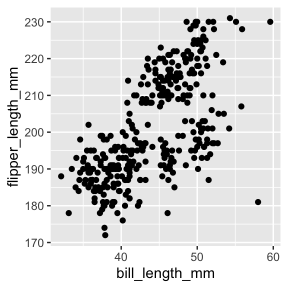

[figure not shown]

```r
penguins %>% ggplot(aes(x = bill_length_mm, y = flipper_length_mm)) + geom_point()
```

There seem to be some clusters

Correlation is below 0.70, but there is a positive linear relationship in some clusters

```r
cor(penguins$bill_length_mm, penguins$flipper_length_mm, use = "pairwise")
```

```
## [1] 0.6561813
```

## Color points

Color points by sex of the penguins, each of the clusters seem to be split about 50/50.

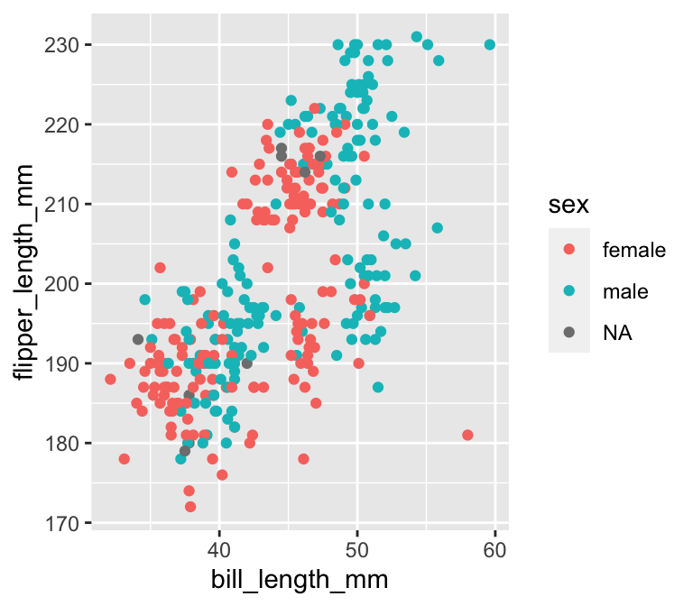

```r
penguins %>%
  ggplot(aes(x = bill_length_mm, y = flipper_length_mm, colour = sex)) +
  geom_point()
```

## Closer look

Clusters are related to different species

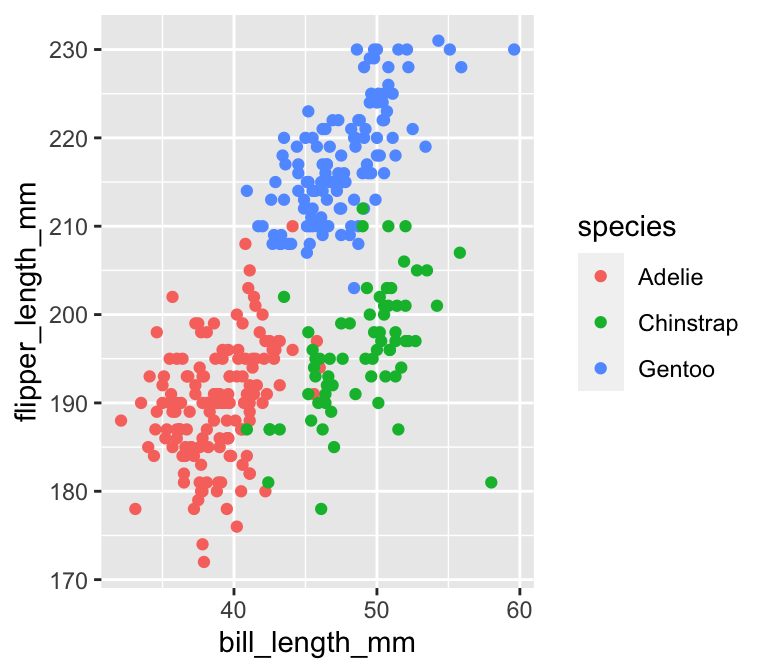

```r
penguins %>%
  ggplot(aes(x = bill_length_mm, y = flipper_length_mm, colour = species)) +
  geom_point()
```

## Meet the Penguins!

[figure not shown]

Artwork by @allison_horst

## Clusters of penguins

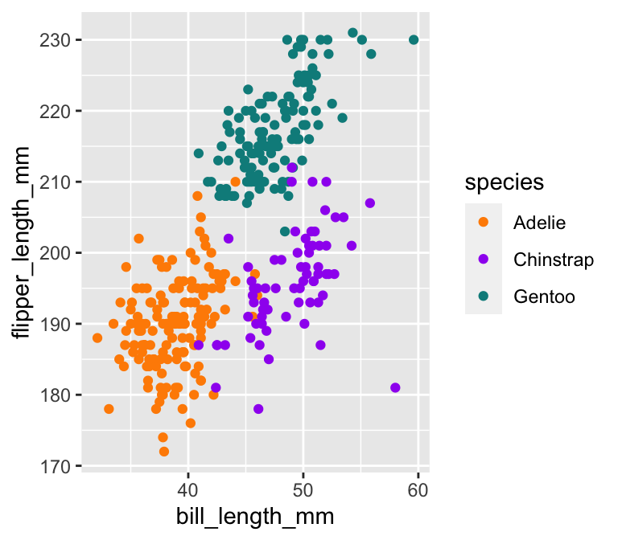

```r
penguins %>%
  ggplot(aes(x = bill_length_mm, y = flipper_length_mm, colour = species)) +
  geom_point() +
  scale_color_manual(values = c("darkorange","purple","cyan4"))
```

## Back to trying to determine gender

Lets look distribution of body mass with a histogram

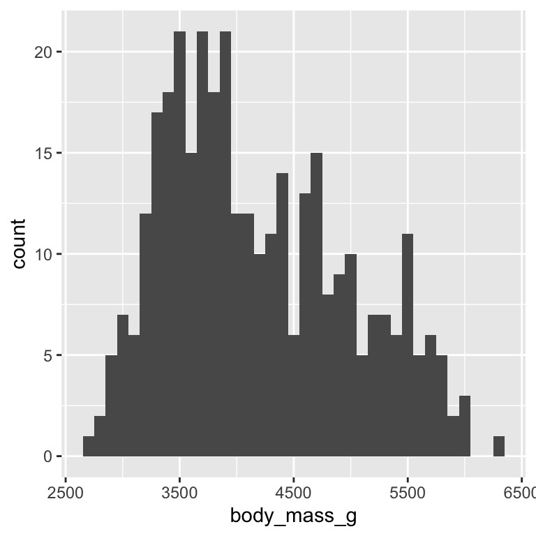

```r
penguins %>%
  ggplot(aes(x = body_mass_g)) + geom_histogram(binwidth = 100)
```

## Back to trying to determine sex of penguins

Lets look distribution of body mass with a histogram colored by sex

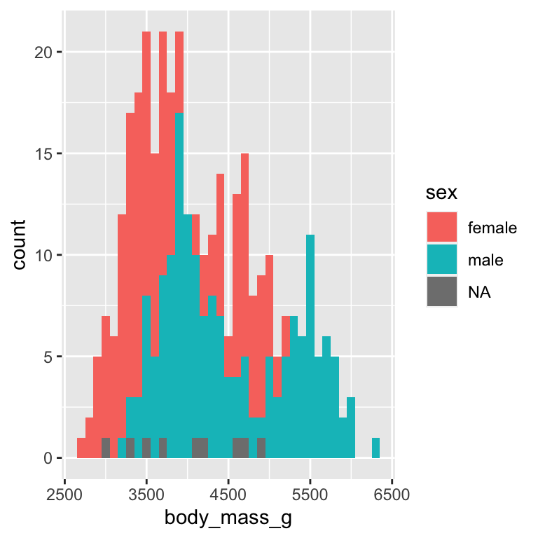

```r
penguins %>%
  ggplot(aes(x = body_mass_g, fill= sex)) + geom_histogram(binwidth = 100)
```

## Body mass and sex of penguins

We can use facetting by species

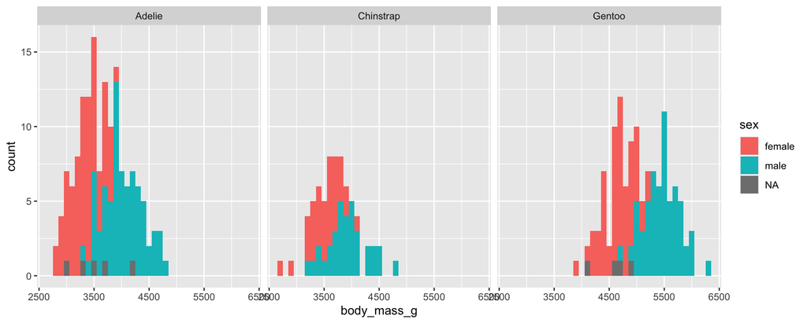

```r
penguins %>%
  ggplot(aes(x = body_mass_g, fill= sex)) + geom_histogram(binwidth = 100) +
  facet_grid(.~species)
```

## Body mass and sex of penguins

We can use facetting by species

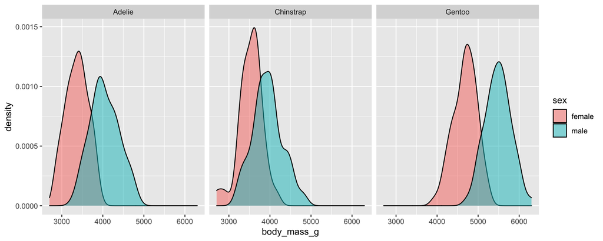

```r
penguins %>% filter(!is.na(sex)) %>%
  ggplot(aes(x = body_mass_g, fill= sex)) + geom_density(alpha = 0.5) +
  facet_grid(.~species)
```

Look at the average body mass for Gentoo penguins separately:

```r
gentoo <- filter(penguins, species=="Gentoo")

mean(gentoo$body_mass_g[gentoo$sex == "male"], na.rm=TRUE)
```

```
## [1] 5484.836
```

```r
mean(gentoo$body_mass_g[gentoo$sex == "female"], na.rm=TRUE)
```

```
## [1] 4679.741
```

## Statistical Significance

There is a difference but is it statistically significant?

```r
t.test(body_mass_g ~ sex, data = gentoo)
```

```
##
##  Welch Two Sample t-test
##
## data:  body_mass_g by sex
## t = -14.761, df = 116.64, p-value < 2.2e-16
## alternative hypothesis: true difference in means between group female and group male is not equal to 0
## 95 percent confidence interval:
##  -913.1130 -697.0763
## sample estimates:
## mean in group female   mean in group male
##             4679.741             5484.836
```

## Your Turn

Try playing with chunks of code from this session to further investigate the penguins data:

1. What is the relationship between penguins bill length and bill depth? What is the correlation? Would you expect the same correlation for all species?
2. What is the median (`median`) bill depths for Adelie and Gentoo penguins? (make sure to use `na.rm = TRUE` to exclude missing values)
3. Is body mass discriminating between male and female Adelie penguins as well as Gentoo penguins?